# Bayesian inference of protein mutant function in high-throughput competition experiments

## Biological Motivation:

Understanding the effects of mutations on a protein sequence is not just a fundamental question in evolutionary biology but also at the core of therapeutic protein drug design. We have measured the effect of 1000s of protein sequence variants in order to learn about such mutation effects. We're trying to understand whether current pairwise abstractions of interacting proteins are useful in predicting the actual next 2 mutational steps across a protein interface.

**Experimental setup**

1000s of bacterial cells expressing different protein variants are competed in a bulk selection assay. The change in frequency of each DNA variant coding for a protein variant is read out using high-throughput DNA sequencing before and after competition. So for each codon variant we measure the count, c_pre, before selection, and the counts after competition, c_aft. The change in count number is a proxy for the growth rate of bacterial cells containing the particular protein variant. Our goal is to estimate these growth rates and their uncertainties. For example, we want to quantify the sampling noise of a protein variant which changes from 2 to 4 read counts, compared to a protein variant going from 20 to 40 read counts.

**Observed data**

**Inference goal**

Infer growth rate of cells containing each protein variant and their uncertainty for downstream analysis.

**Downstream goals**

Interpretation of mutations in terms of structural/dynamic mechanisms, and comparison to mutation prediction from natural sequences.

### Motivation for performing Bayesian analysis:

**1. interpretability**:

Inherently, we are interested in whether and how much a given mutation rescues the growth rate, compared to the wt sequence, which is the posterior Bayesian credible interval. The frequentist confidence interval would ask something along the lines of whether a particular mutant differs in it's growth rate (reject the null hypothesis or not).

A frequentist confidence interval is not a probability distribution over your parameter of interest. Instead it constructs an interval, which, under repeated sampling of datasets from your null distribution, would contain the true (fixed) parameter a particular fraction of times (with a confidence level 95%). This is different from what you're usually interested in, which is actually a Bayesian credible interval over your parameter (ie. of the posterior probability). Of course practically, these could be very similar.

see for example: https://www.ncbi.nlm.nih.gov/pubmed/26620955

and Andrew Gelman and Deborah Nolan's Book: teaching statistics: a Bag of tricks. nice viz of confidence intervals: https://seeing-theory.brown.edu/frequentist-inference/index.html#section2

**2.Philosophical**: satisfying the likelihood principle.

Frequentist null hypothesis significance testing asks the question: What is the probability of observing data at least as extreme as my observed data under a given null hypothesis, H0. The issues is that H0 influences all the possible datasets that I could've observed, which depends on my experimental design such as my stopping rule for data collection. This means there are multiple p-values for a given sequence, depending on H0.

A concrete example might be trying to assess whether an observed sequence of coin tosses (HTHTTTH) comes from a fair coin. Depending on whether the experiment was conducted until a certain number of coin flips were performed, or until a certain number of heads was observed, the space of possible observed coin toss sequences differs. The probability of a particular sequence in the former follows a binomial probability distribution, versus the latter a negative binomial distribution. These will give different p-values. David MacKay puts this weirdness clearly: Experimenter A who conducts the experiment inside of a room, should come to the same conclusion as experimenter B, who just watches the outcomes of the experiment through the window without knowing the experimental design.

**3. Practical**:

Bayesian modeling allows us to specify complex structures in the data generating process, and infer our parameters of interest by integrating out the parameters that we are not interested in. It also allows for hierarchical models that come with all the benefits of shrinkage and pooling of information across groups. See the classical example of estimating treatment effect among different small groups: https://statmodeling.stat.columbia.edu/2014/01/21/everything-need-know-bayesian-statistics-learned-eight-schools/

```python
%load_ext autoreload
%autoreload 2

from my_imports import *


import pystan
import arviz as az
import stanMods as smods
import bayesTools
import py3Dmol

pi_dir = '/Users/davidding/Dropbox (HMS)/parESingleLibrary/ex51_set_up_additional_mutants/illumina/pickles/'
```

```
The autoreload extension is already loaded. To reload it, use:
  %reload_ext autoreload
```

### Visualize protein of interest

```python
# interactive visualization of our protein of interest
plt.figure(figsize=(15, 15))
p = py3Dmol.view(query="pdb:5ceg")

# antitoxin is wheat colored
p.setStyle({"chain": "A"}, {"cartoon": {"color": "wheat"}})
p.setStyle({"chain": "C"}, {"cartoon": {"color": "wheat"}})
# toxin is grey
p.setStyle({"chain": "B"}, {"cartoon": {"color": "grey"}})
p.setStyle({"chain": "D"}, {"cartoon": {"color": "grey"}})
```

You appear to be running in JupyterLab (or JavaScript failed to load for some other reason). You need to install the 3dmol extension:  
`jupyter labextension install jupyterlab_3dmol`

```
<py3Dmol.view at 0x1c253f9c18>
```

### Model description

The model we have is shown in plate notation below.

There are n observed counts before selection, c_pre, and c_post. This corresponds to all possible codon mutations along the toxin.

There are m latent growth rates r, that we are interested in. This corresponds to the m different amino acid mutant growth rates. n >= m since for example a given amino acid mutation we might observe multiple synonymous codon changes.

We put a vague prior on r with Normal(1,10).

Finally, f_pre and f_post are Poisson parameters for the counts, with f_pre being drawn from the conjugate Gamma distribution (parameterize by alpha and beta), and f_post is a multiplication of f_pre with r_m.

Finally, we are interested in the relative ratio of r for a given amino acid mutant versus the wt r, diff_r.

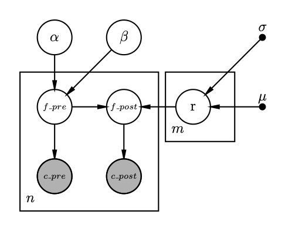

```python
from IPython.display import Image
Image("img/bayes_dag.jpg")
```

### Load count data

```python
# datasets for biological replicate 1 and 2
data_r1 = pickle.load(open(pi_dir + 'data_r1.csv', 'rb'))
data_r2 = pickle.load(open(pi_dir + 'data_r2.csv', 'rb'))
```

### Compile model

```python
sm = pystan.StanModel(model_code=smods.diff_r_model)
with open('./sm.pkl', 'wb') as f:
    pickle.dump(sm, f)
```

```
INFO:pystan:COMPILING THE C++ CODE FOR MODEL anon_model_b9025d960c006730581bd5c89e2cab7b NOW.
```

### Perform bayesian inference

```python
fit_r1 = sm.sampling(data=data_r1, iter=2000, chains=2, seed=3, control={'max_treedepth': 15})
fit_r2 = sm.sampling(data=data_r2, iter=2000, chains=2, seed=3, control={'max_treedepth': 15})
```

```
WARNING:pystan:Maximum (flat) parameter count (1000) exceeded: skipping diagnostic tests for n_eff and Rhat.
To run all diagnostics call pystan.check_hmc_diagnostics(fit)
WARNING:pystan:Maximum (flat) parameter count (1000) exceeded: skipping diagnostic tests for n_eff and Rhat.
To run all diagnostics call pystan.check_hmc_diagnostics(fit)
```

```python
#pickle and convert to dataframe
with open(pi_dir + 'fit_r1.pi', 'wb') as f:
    pickle.dump(fit_r1, f)

with open(pi_dir + 'fit_r2.pi', 'wb') as f:
    pickle.dump(fit_r2, f)

df_fit1 = fit_r1.to_dataframe()
df_fit2 = fit_r2.to_dataframe()
```

### Check inference

Can you trust the HMC samples? Have the MCMC chains converged? Are there numerical issues, such as divergences arising?

```python
pystan.check_hmc_diagnostics(fit_r1)
```

```
{'n_eff': True,
 'Rhat': True,
 'divergence': True,
 'treedepth': True,
 'energy': True}
```

```python
pystan.check_hmc_diagnostics(fit_r2)
```

```
{'n_eff': True,
 'Rhat': True,
 'divergence': True,
 'treedepth': True,
 'energy': True}
```

### Perform posterior predictive checks (PPCs)

Using PPCs to validate whether model is consistent with the observed data. Comparing observed data statistic to statistic of generated data from the model's posterior.

for more information see Gelman, et al. Bayesian Data Analysis 3: chapter 6.3

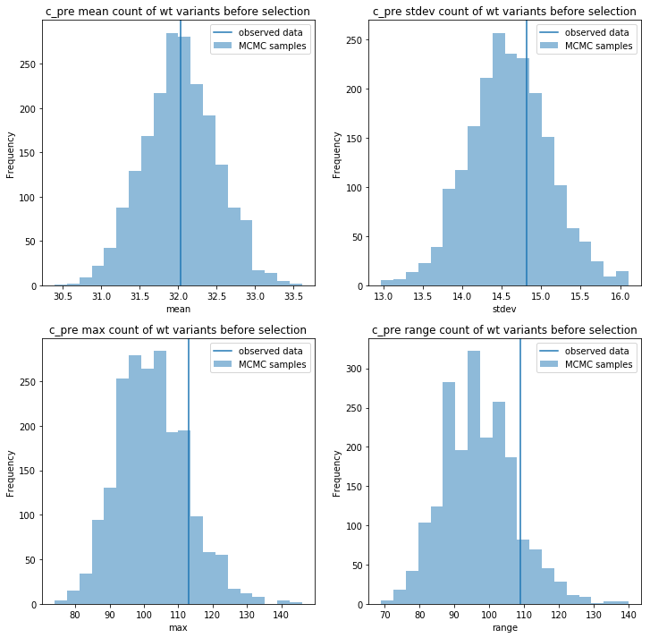

```python
bayesTools.plot_all_ppcs(df_fit1, 'c_pre', data_r1)
```

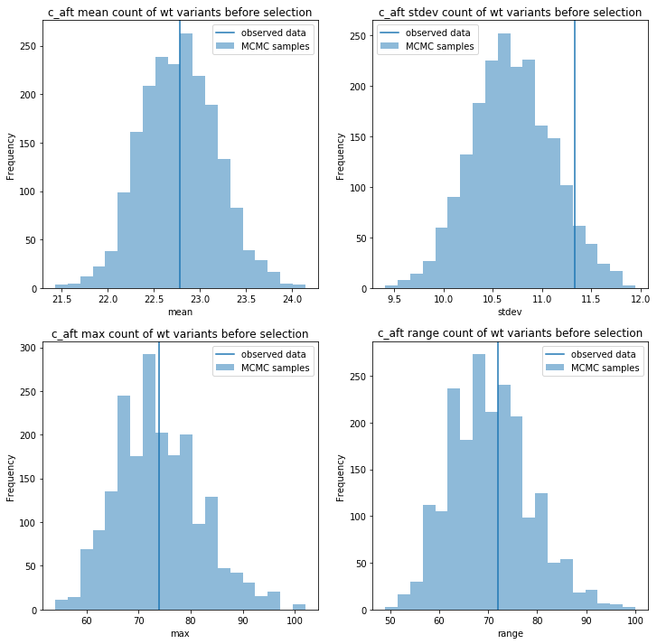

```python
bayesTools.plot_all_ppcs(df_fit1, 'c_aft', data_r1)
```

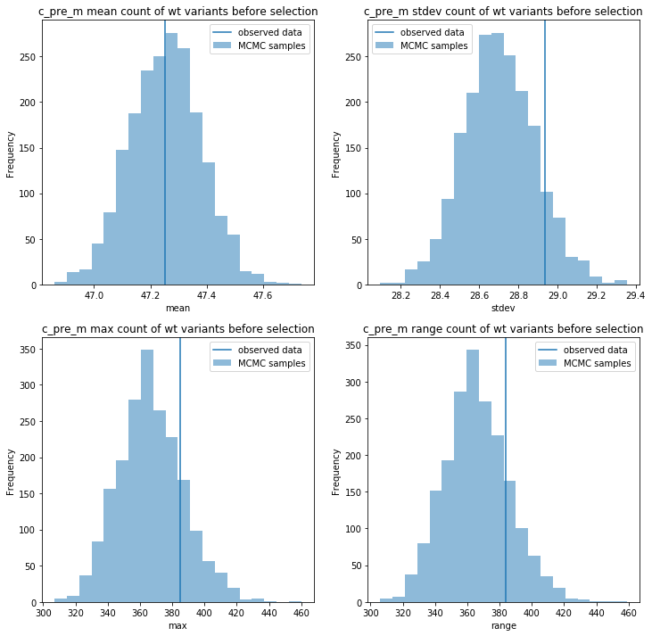

```python
bayesTools.plot_all_ppcs(df_fit1, 'c_pre_m', data_r1)
```

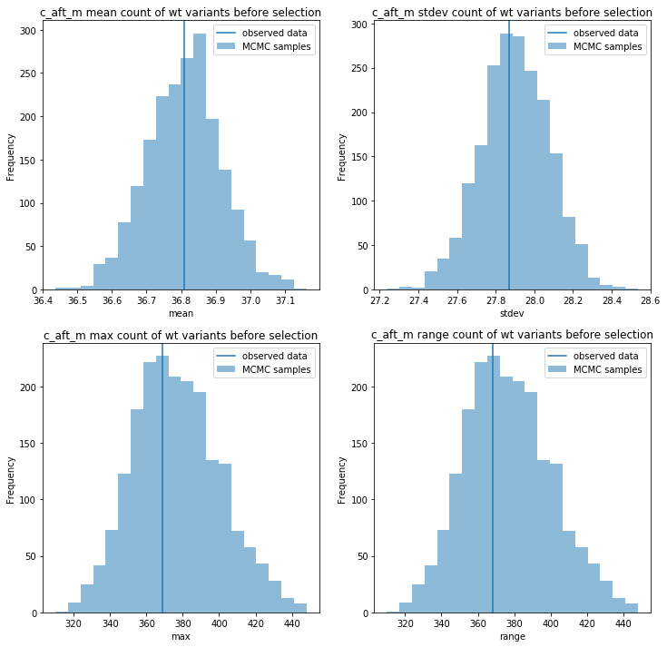

```python
bayesTools.plot_all_ppcs(df_fit1, 'c_aft_m', data_r1)
```

## What is the biological reproducibility?

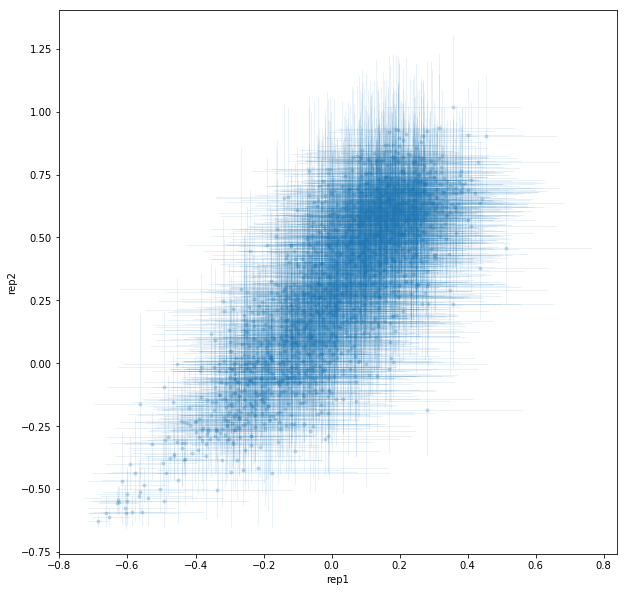

```python
d_aakey = pickle.load(open(pi_dir+'aa_dic.p', 'rb'))
bayesTools.plot_corr_reps_errs(d_aakey,df_fit1, df_fit2)
```

## Plot amino acid fitness heatmap

```python
%autoreload
# create df_rm that has amino acid index
df_rm = bayesTools.create_df_mean_hdi(d, df_fit1)
df_rm.head()
```

|  | aa_mut | num | col | mean_fit | hdi_lower | hdi_upper |
| --- | --- | --- | --- | --- | --- | --- |
| 0 | A10D | 1 | diff_r[1] | 0.188989 | -0.016101 | 0.397630 |
| 1 | A10E | 2 | diff_r[2] | 0.220222 | 0.034214 | 0.414552 |
| 2 | A10F | 3 | diff_r[3] | 0.316649 | 0.075197 | 0.579777 |
| 3 | A10G | 4 | diff_r[4] | 0.325846 | 0.112166 | 0.562826 |
| 4 | A10H | 5 | diff_r[5] | 0.220067 | 0.081778 | 0.355870 |

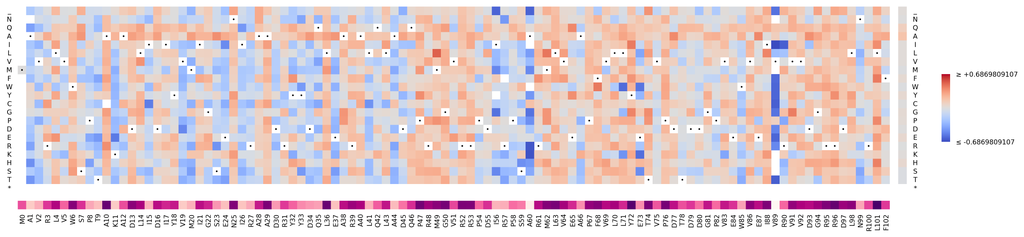

```python
bayesTools.plot_fitness_heatmap_aa(df_rm)
```

### Future model extensions: model misspecification?

How robust are the inferences to model misspecification?

Determine sensitivity to changes in likelihood model or priors. For example, there is potential to introduce hierarchical modeling of mutant amino acid synonymous read ratios.

Could try out fixes such as BayesBag, ie. the average posterior distribution under bootstrapped datasets. http://jhhuggins.org/publication/bayesbag/